# RigidBody

# RigidBody moves with physics

The `RigidBody` node lets you move objects using physics. You apply forces, impulses, and torque to move objects in your scene.

`RigidBody` handles gravity and collisions out of the box, so you get up and running with minimal coding.

This force-based approach contrasts with a `KinematicBody` which you move and rotate by hand. Choosing between these two is a tradeoff between precise controls and automated physics.

`RigidBody` is incredibly versatile. You can use it for bouncing grenades, push-able blocks, destructible terrain, and much more.

In this guide, you will learn how to:

- Create a 3D platforming player controller with `RigidBody`.
- Push bodies with forces in an explosion.
- Simulate gravity and collisions.
- Shatter crates into shards with physics.

Contents:

- Setting up a RigidBody
- RigidBody key features
  - Forces and impulses
  - The RigidBody’s four modes
  - Mass, weight, and gravity scale
  - Reporting contacts
  - Physics materials
- How to use a RigidBody in practice
  - Making a 3D platforming player controller
  - Make an explosion with forces
  - Creating structures that collapse and fall over
  - Turning bodies into debris with a pre-shattered model
- Your questions
  - When should I use a RigidBody over a KinematicBody?
  - How can I make something float?
  - What is sleeping?
  - Can I scale my rigid body?

## Setting up a RigidBody

In Godot, physics nodes need a `CollisionShape` or `CollisionPolygon` as a child to define their collider.

This is also true of Area, KinematicBody, and `StaticBody`.

The collision shape lets them figure out when they are touching or overlapping other bodies.

You need three components for a `RigidBody` to work:

1. The `RigidBody` node, which handles forces applied to itself.
2. One or more `CollisionShape` or `CollisionPolygon` nodes that define the collider of the `RigidBody`.
3. Each `CollisionShape` has a collision shape like a `BoxShape` or a collider based on a mesh, like a `ConcavePolygonShape`. Alternatively, a `CollisionPolygon` has an array of points and an extrude *Depth*.

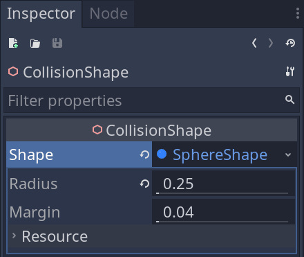

You also need to add a mesh to make the `RigidBody` visible: this is usually a `MeshInstance`, but you could also use a `CSGMesh`.

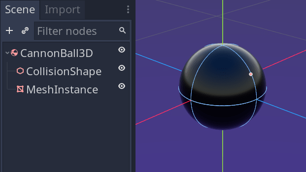

You can also enable *Visible Collision Shapes* in the *Debug* dropdown menu to see the colliders when testing the game.

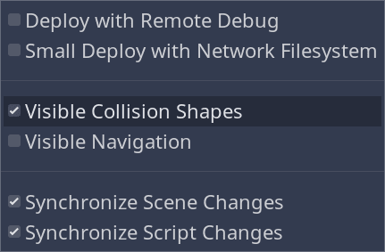

## RigidBody key features

The `RigidBody` has many properties that control how it should react to forces. A lot of its setup involves tweaking physics properties in the editor.

### Forces and impulses

You control motion on rigid bodies with force and impulse functions:

#### Applying forces and impulses

You can apply a force with `add_central_force()` or `add_force()`.

A central force only moves a body from its center of mass, while `add_force()` lets you move the body from any local position.

The node may rotate if you offset the force from its center of mass with `add_force()`.

To apply an impulse, you want to call `apply_central_impulse()` or `apply_impulse()`. They work the same as force-related methods, except they apply for one frame.

**Note:** Applying impulses every frame makes your force framerate-dependent. If the player’s framerate goes down, your bodies’ motions slow down too.

That’s why you only want to use those methods for one-time impulses, like explosions.

Alternatively, you can multiply your impulse by the time since the last physics update when overriding the `_integrate_forces()` virtual method. The function provides a `state.step` value: the time interval between two physics ticks.

You’ll see below how we use `state.step` in concrete use cases.

#### Applying rotational forces

While the `add_force()` and `apply_impulse()` methods can cause a body to rotate on top of moving, you may want only to apply a rotational force. We apply rotational forces with torque.

You can use torque for many effects, like turning a wheel or making a body look at another.

To apply constant torque, use the `add_torque()` method. For a one-time rotational impulse, you’ll use `apply_torque_impulse()` instead.

#### Integrating forces

Unlike other bodies, you don’t want to directly change the `position` of a `RigidBody` inside `_physics_process()`. To combine your motion with the physics engine, you need to use its state.

To do so, you want to override and use the `_integrate_forces()` virtual function. This function contains a `PhysicsDirectBodyState` object called `state`. You can call functions on this object or access variables like `linear_velocity` to get the body’s speed.

Accessing properties using this `state` ensures they are up to date following collisions, forces, and impulses.

You’ll see some examples in this guide.

### The RigidBody’s four modes

A `RigidBody` has four modes that change its general behavior:

- By default, a `RigidBody` uses the *Rigid* mode. In this mode, gravity affects the body, and it pushes other bodies during collisions.
- The *Static* mode makes your `RigidBody` completely stationary. It is useful when enabling and disabling doors, locking objects in place.
- The *Character* mode is ideal for player characters. It behaves similarly to *Rigid* mode but won’t rotate on its own. This mode ensures a player’s character remains upright.
- Finally, *Kinematic* is a helpful mode for manually making changes to a body. This mode makes the `RigidBody` work similarly to a `KinematicBody`: it doesn’t integrate forces, and you have to change its position manually. Use it to take manual control over a character, or in cases where you need to teleport the body to a precise location.

You can control the active mode using the node’s *Mode* property.

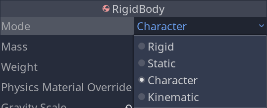

You can switch mode on the fly depending on your needs. For instance, a character can go from the *Character* mode to *Rigid* when dying, causing it to get pushed around by other bodies.

### Mass, weight, and gravity scale

These three properties greatly affect how a `RigidBody` moves:

1. *Mass* represents how hard to move the object is.
   - The higher the value, the more force you need to move it.
   - The lower the value, the easier it is to move.
   - The body’s center of mass is at the node’s origin.
2. Weight is *Mass* multiplied by the *Default Gravity*, so updating the mass updates its weight in turn.
3. *Default Gravity* is a project-wide setting.
   - The physics engine applies it to every `RigidBody` to make them move down towards the ground.
   - You can change it by going to *Project Settings -> Physics -> 3D -> Default Gravity*.

If you want objects to fall faster, you need to increase this in project settings. You can also increase the gravity scale on your `RigidBody` itself.

Note that *Mass* and *Weight* do not affect the speed at which an object falls.

This relationship is the same as the real world: all objects fall at the same speed. [See the hammer and feather experiment on the Moon](https://youtu.be/KDp1tiUsZw8).

You either need to increase gravity or apply an extra downwards force to make an object fall faster. We’ll see how to apply forces in the examples below.

### Reporting contacts

`RigidBody` has four convenient signals to detect and react when it touches something.

The main two are `body_entered` and `body_exited`. The signals work similarly to `Area`’s signals: the callback tells you what you hit when a collision happens.

You can use them to trigger an explosion when touching a mine, to inflict damage, and more.

By default, rigid bodies don’t report collisions and points of contact for performance reasons. If the collisions happen, the node won’t emit signals.

If you want the node to emit these signals, there are two steps:

1. Turn on *Contact Monitor* to get collision reports.
2. Increase *Contacts Reported* to the number of contacts you want to support. Once the node emits this number of signals, it ignores the rest in that frame.

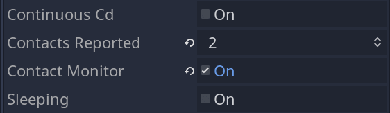

As a rule of thumb, you can set contacts reported relatively high if you are dealing with one object.

If you have many objects detecting collisions, you want to limit the reported contacts for performance.

You’ll have to play with the *Contacts Reported* property in your game to see what works for you.

### Physics materials

Physics materials let you fine-tune how rigid bodies interact with each other.

You can save a `PhysicsMaterial` as a resource and assign it to any `RigidBody`’s *Physics Material Override* to reuse it.

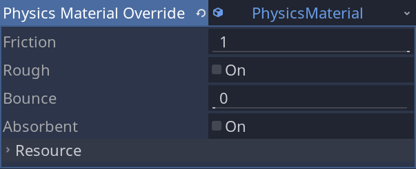

The properties you can control are *Friction*, *Rough*, *Bounce*, and *Absorbent*:

- *Friction* determines how much an object slows when colliding with another. It can be useful to set *Friction* low on a player character; otherwise, they move slower on the floor due to gravity.
- *Rough* is a toggle that determines how bodies with different frictions interact. If a body is rough, both colliding bodies use the highest friction. In short, this lets you slow down objects that collide with this body.
- *Bounce* determines momentum lost in each collision. With `0` *Bounce*, an object stops immediately. A *Bounce* of `1.0` means the body changes direction instead of losing momentum. Think of a basketball hitting the floor versus wet tissue paper.
- *Absorbent* is a toggle that determines how bodies with different *Bounce* interact. The engine subtracts the *Bounce* of the *Absorbent* body from the colliding body. In short, a bouncy object colliding with an absorbent body bounces less.

## How to use a RigidBody in practice

### Making a 3D platforming player controller

Many games take advantage of rigid player characters with physics: pinball machines, birds in *Angry Birds*, and worms in *Worms*.

Rigid physics are ideal for games where you want to crash into lots of objects in your world.

Here, you’ll see how to create a 3D platforming game character that walks and jumps with a `RigidBody`.

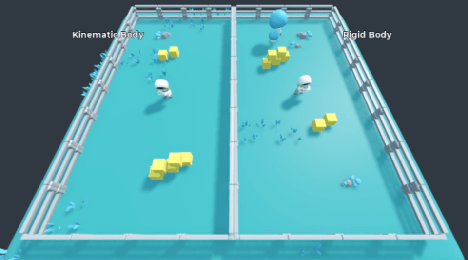

Making a player with a `RigidBody` is convenient as Godot handles gravity automatically. We couldn’t recommend it for all platformers, but using a `RigidBody` over a `KinematicBody` can be very helpful.

You can use a `RigidBody` in the *Character* mode for a platform game controller.

In this example, we use a *Physics Material Override* without any friction to stop gravity slowing your movement down as the physics engine pushes you into the floor.

*Contacts Reported* determines how many collisions Godot pays attention to per frame. If this number isn’t high enough, we can miss collisions with the floor. We need them to know that the character is on the floor and can jump.

For a platforming character in a game with curved terrain or slopes, you can set this number to at least `3` or `4`.

You can then use the `_integrate_forces()` virtual function to apply impulses or forces based on the player’s inputs.

```
func _integrate_forces(state: PhysicsDirectBodyState) -> void:
    if _should_reset:
        state.transform.origin = _start_position
        _should_reset = false

    _move_direction = _get_camera_oriented_input()

    # To not orient quickly to the last input, we save a last strong direction,
    # this also ensures a good normalized value for the rotation basis.
    if _move_direction.length() > 0.2:
        _last_strong_direction = _move_direction.normalized()

    _orient_character_to_direction(_last_strong_direction, state.step)

    if is_jumping(state):
        _model.jump()
        apply_central_impulse(Vector3.UP * jump_initial_impulse)
    elif is_air_boosting(state):
        add_central_force(Vector3.UP * jump_additional_force)

    add_central_force(_move_direction * move_speed)
```

The `_get_camera_oriented_input()` and `_orient_character_to_direction()` functions are identical to the ones we use in KinematicBody to manage 3D cameras and character rotation.

```
func _get_camera_oriented_input() -> Vector3:
    var input_left_right := (
        Input.get_action_strength("move_right")
        - Input.get_action_strength("move_left")
    )
    var input_forward_back := (
        Input.get_action_strength("move_down")
        - Input.get_action_strength("move_up")
    )

    var raw_input = Vector2(input_left_right, input_forward_back)

    var input := Vector3.ZERO
    # This ensures correct analogue input strength in any direction with a joypad stick
    input.x = raw_input.x * sqrt(1.0 - raw_input.y * raw_input.y / 2.0)
    input.z = raw_input.y * sqrt(1.0 - raw_input.x * raw_input.x / 2.0)

    input = _camera_controller.global_transform.basis.xform(input)
    return input

func _orient_character_to_direction(direction: Vector3, delta: float) -> void:
    var left_axis := Vector3.UP.cross(direction)
    var rotation_basis := Basis(left_axis, Vector3.UP, direction).get_rotation_quat()
    var model_scale := _model.transform.basis.get_scale()
    _model.transform.basis = Basis(_model.transform.basis.get_rotation_quat().slerp(rotation_basis, delta * rotation_speed)).scaled(
        model_scale
    )
```

As `RigidBody` doesn’t have a convenient `is_on_floor()` function, unlike `KinematicBody`, we need to code it ourselves.

```
func is_on_floor(state: PhysicsDirectBodyState) -> bool:
    # Contacts_reported needs to be high enough to count all surfaces on body
    for contact in state.get_contact_count():
        var contact_normal = state.get_contact_local_normal(contact)
        # If the contact is below us we are on the floor
        if contact_normal.dot(Vector3.UP) > 0.5:
            return true
    return false
```

### Make an explosion with forces

Your scenes feel more interactive if the world reacts to big forces like explosions.

When making an explosion, you want objects and rubble to blast away from the origin. `RigidBody` nodes are great for this as you can apply explosive impulses to them.

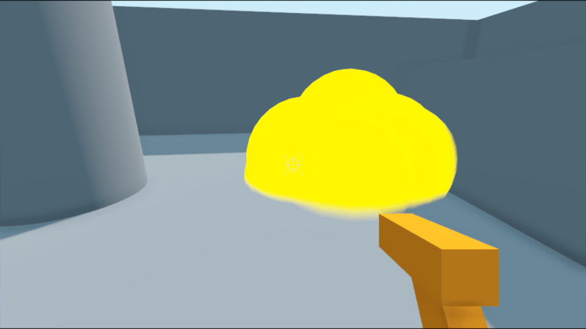

In this example, we instance a grenade, which is itself a `RigidBody`. It contains an explosion particle system and an `Area` node to determine the radius of the blast.

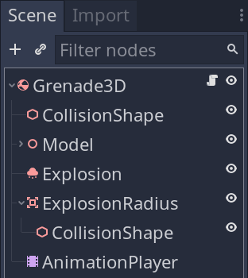

We use an animation to time the grenade’s explosion.

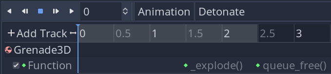

The `_explode()` function hides the grenade model, starts the particle system, and applies the physics force of the explosion to objects within the *ExplosionRadius* `Area`.

```
func _explode() -> void:
    _model.hide()
    _explosion.set_as_toplevel(true)
    _explosion.emitting = true

    var colliders = _explosion_area.get_overlapping_bodies()
    for body in colliders:
        if body is RigidBody:
            var direction := global_transform.origin.direction_to(body.global_transform.origin)
            body.apply_central_impulse(blast_impulse * direction)
```

### Creating structures that collapse and fall over

Many games benefit from objects that react to physics. Be it boxes you push around, pressure plates, destructible terrain, or walls collapsing.

Here, we cover the example of a scene with a tower that you can knock over with a cannonball.

Clicking fires a projectile. If the projectile touches the tower with the right trajectory, it can knock over its supports.

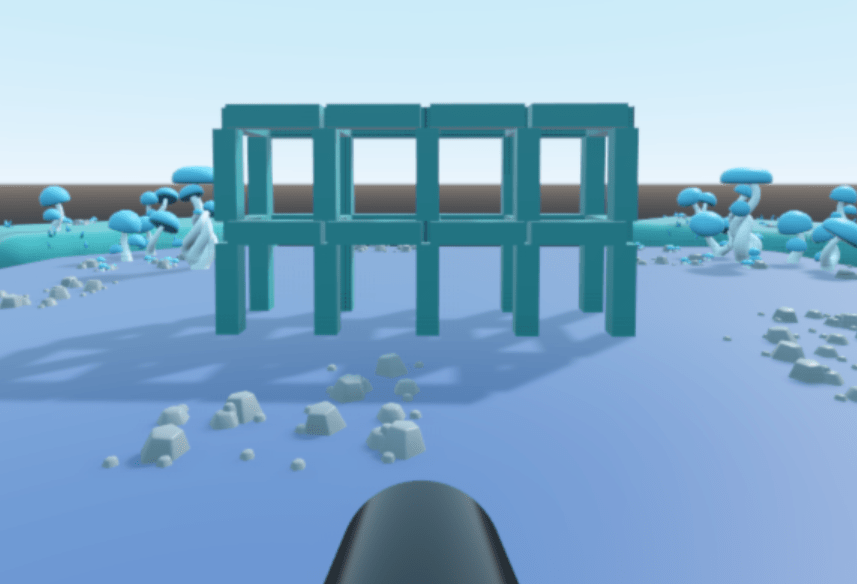

With `RigidBody`, you get that functionality almost for free. Make both your cannonball and the structure use rigid bodies.

The cannonball has no logic; it’s just a `RigidBody`. The cannon, on the other hand, needs to spawn and fire the projectiles.

We capture mouse input in two variables `_yaw_input` and `_tilt_input` in the `_unhandled_input()` function.

```
func _unhandled_input(event: InputEvent) -> void:
    if Input.get_mouse_mode() == Input.MOUSE_MODE_CAPTURED:
        if event is InputEventMouseMotion:
            _yaw_input = -event.relative.x * mouse_sensitivity
            _tilt_input = -event.relative.y * mouse_sensitivity
```

We then rotate the cannon based on the input while clamping the rotation to limit the cannon’s movement.

```
    rotate_y(_yaw_input * rotation_speed * delta)
    rotation_degrees.y = clamp(rotation_degrees.y, yaw_lower_limit, yaw_upper_limit)

    _tilt_pivot.rotate_x(_tilt_input * tilt_speed * delta)
    _tilt_pivot.rotation_degrees.x = clamp(
        _tilt_pivot.rotation_degrees.x, tilt_lower_limit, tilt_upper_limit
    )
```

Suppose the player presses a specific button and our firing rate timer is not running. In that case, we instantiate a cannonball and set it as *top level* so it moves independently from its parent. Then we can apply an impulse in the direction the cannon is pointing.

```
    if Input.is_action_just_pressed("shoot_3d") and _timer.is_stopped():
        _timer.start()
        var cannon_ball: RigidBody = cannon_ball_scene.instance()
        _launch_point.add_child(cannon_ball)
        cannon_ball.set_as_toplevel(true)
        cannon_ball.apply_central_impulse(-_launch_point.global_transform.basis.z * cannon_power)
```

For the structure, you want to create individual rigid bodies with a collision shape and place them in the editor.

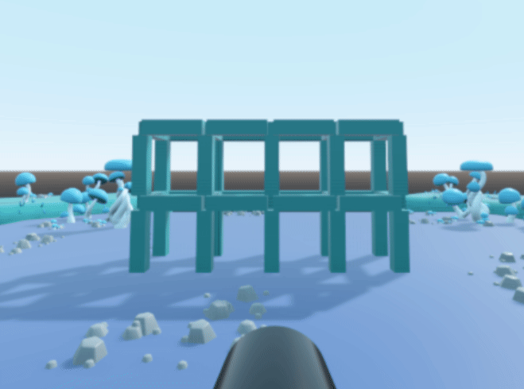

These objects have many properties that let you fine-tune their behavior:

- The higher their *Mass*, the more velocity the cannonball needs to knock them down.
- If you want your bodies to fall faster, you can increase their *Gravity Scale* or add an applied force downwards via code.

For the cannonball, you can add a *Physics Material* to get access to more properties. Like *Bounce* and *Friction*.

If your objects are rolling around too much, increase their *Angular Damping* property. This property is beneficial for circular bodies that tend to roll easily.

### Turning bodies into debris with a pre-shattered model

Sometimes you might want to have an object explode into tiny pieces and collide with physics—shattered glass, a splintering crate, or an enemy exploding into giblets.

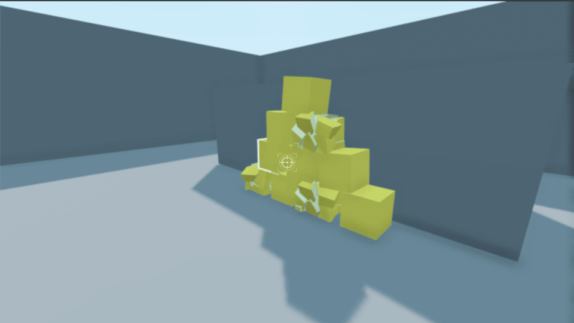

Here, we have a crate shatter into shards when clicked. The fragments tumble about, interacting with each other and the environment.

This effect looks complicated but is actually a simple trick. The crates are `RigidBody` nodes. On breaking, a shattered version of the crate, made up of many smaller `RigidBody` nodes, replaces the original.

The shattered box is made using Blender and imported as a `glTF` file. Using the *-rigid* suffix on each shard causes Godot to import each shard as a `RigidBody` with a generated `ConvexPolygonShape` `CollisionShape`. Read more about import suffixes [here](https://docs.godotengine.org/en/stable/getting_started/workflow/assets/importing_scenes.html). You can easily add the suffix to multiple objects in Blender using the *Batch Rename* function in Blender.

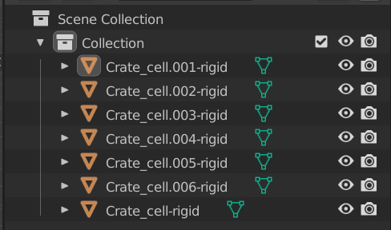

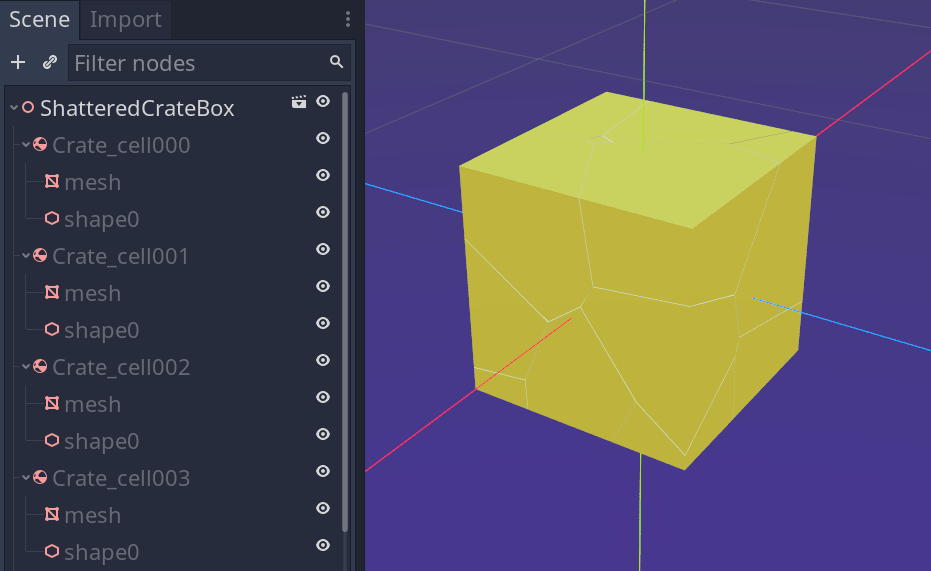

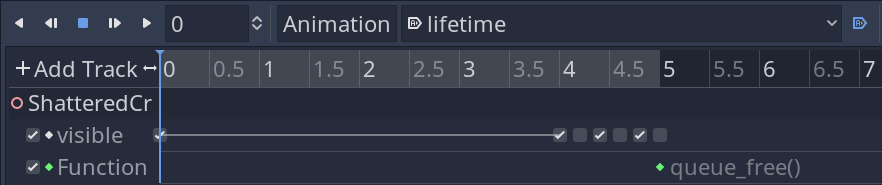

```
export var shattered_crate_scene: PackedScene

func shatter() -> void:
    var shattered_crate: Spatial = shattered_crate_scene.instance()
    get_parent().add_child(shattered_crate)
    shattered_crate.global_transform = global_transform
    queue_free()
```

## Your questions

### When should I use a RigidBody over a KinematicBody?

Rigid bodies are great for many different game objects: ropes, fluids, traps, jump pads, motors, simple enemies, and much more.

Consider using a `RigidBody` if your player exerts forces on or is forced by other bodies.

They are also popular for mobile games, as you can have lots happening with simple inputs. This is known as emergent gameplay: simple rules causing complex behaviors.

### How can I make something float?

Using *Gravity Scale*, you can make any object float with ease. The *Gravity Scale* is a multiplier for the default gravity applied to a body. You can increase it to make a body fall faster.

Setting *Gravity Scale* to `0.0` makes an object float in place as no gravity acts on the body. You can take this a step further and put the *Gravity Scale* to `-1.0`.

A negative *Gravity Scale* makes an object fall upwards instead of falling to the ground, creating things like balloons. As this negative gravity exerts a force, you can use a pin joint to exert upwards on other bodies.

### What is sleeping?

When a body is asleep, it acts as a static body. Being asleep means the `_integrate_forces()` function doesn’t run until a collision or code applies a force. Sleeping is useful for reducing function calls if you have many rigid bodies.

The *Can Sleep*, and *Sleeping* properties determine when a `RigidBody` goes to sleep. You can set the *Sleeping* property manually; it tells us if the body is asleep. The *Can Sleep* property tells us if the physics engine can automatically update the value of *Sleeping* after a duration at rest with no active forces.

The *Can Sleep* property updates *Sleeping* with the physics engine. Rigid bodies have the `sleeping_state_changed` signal for notifying you when the sleeping state of a body has changed.

**Note:** A body set to *Character* mode never goes to sleep automatically, but you can still set it manually.

### Can I scale my rigid body?

Don’t scale your rigid bodies! Instead, change the size of the shape directly.

Collision shapes easily break when you change their scale dynamically. Changing the scale of a physics body doesn’t apply any forces and leads to unexpected behavior.

If you want to change the scale of a `PhysicsBody`, you should access the size values of your shape directly.

Another option is to create multiple collision shapes for a body and disable those not at the current size, enabling shapes and scaling the mesh instances separately.

Unexpected behavior can occur when changing the size of a body in too small a space. It is worth using one or more `RayCast` to detect if your body has enough space to expand.